# Assignment 17: Data Simulation

*How to do it?*:

- Open the Rmarkdown file of this assignment (link) in Rstudio.
- Right under each **question**, insert a code chunk (you can use the hotkey `Ctrl + Alt + I` to add a code chunk) and code the solution for the question.
- `Knit` the rmarkdown file (hotkey: `Ctrl + Alt + K`) to export an html.
- Publish the html file to your Githiub Page.

*Submission*: Submit the link on Github of the assignment to Canvas

**Notice:** *In this assignment, all the plot should have title, caption, and axis labels.*

### 1. Simulating Data for a model

Suppose we want to simulate data from the following linear model

$$y = 2 + 3 x + \epsilon$$
where $\epsilon \sim N(0, 1)$.

To simulate data, we first need specify values for $x$. We use `rnorm` to generate data from the normal distribution and `runif` to generate data from the uniform distribution.

```r
n = 1000
x = runif(n = n, 0, 10)
e = rnorm(n=100, mean = 0, sd = 1)
y = 2+3*x + e
```

Use the linear model to estimate the coefficient with the simulated the data.

```r
lm(y~x)
```

```
##
## Call:
## lm(formula = y ~ x)
##
## Coefficients:
## (Intercept)            x
##       1.809        2.991
```

We see that the linear model does a very good job estimating the true value of the coefficients.

Do the follows.

- Simulate data for the following model and use linear model to recover the coefficients. How well the linear model fits the data?

```r
n = 1000
x1 = runif(n = n, 0, 10)
x2 = runif(n = n, 0, 10)
e = rnorm(n=100, mean = 0, sd = 2)
y= 2 + 3*x1 + 4*x2 + e
lm(y~x1)
```

```
##
## Call:
## lm(formula = y ~ x1)
##
## Coefficients:
## (Intercept)           x1
##      21.259        3.111
```

```r
lm(y~x2)
```

```
##
## Call:
## lm(formula = y ~ x2)
##
## Coefficients:
## (Intercept)           x2
##      16.585        4.095
```

```r
#The coefficients that they simulated are extremely close to the correct 3 and 4 coefficients in the problem. That means that the linear model is fitting the data accurately and extremely well.#
```

$$y = 2 + 3 x_1 + 4x_2 + \epsilon$$
where $\epsilon \sim N(0, 2)$.

### 2. Simulating Data to test the Central Limit Theorem

The central limit theorem says that the sample means of any distribution follows the normal distribution with the same population mean. Do the follows to verify the theorem

- Generate 1000 samples from uniform distribution, each sample has the size $n$
- Calculate the means of all the samples
- Plot the histogram of the means and verify that the histogram shows the normal distribution of the means.

Redo the above steps for the distribution of the number of values getting when rolling a die. [Hint: Use `sample(1, 6, n, replace = TRUE)` to generate samples from rolling a die]

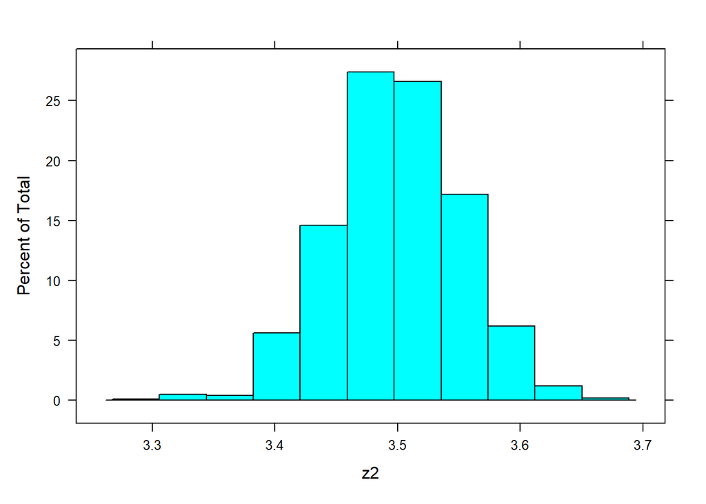

```r
library(lattice)
n = 1000000
z <- sample(6, n, replace = TRUE)
z1 <- matrix(z, nrow=1000)
z2 <- rowMeans(z1)
histogram(z2)
```

### 3. (Monte Carlo Methods) Estimating Pi

[figure not shown]

Do the following to estimate $\pi$

- Generating n = 1000 values of $x$ from -1 to 1 using `runif`

```r
n = 1000
x = runif(n = n, -1, 1)
t <- x
```

- Generating n = 1000 values of $y$ from -1 to 1 using `runif`

```r
n = 1000
y = runif(n = n, -1, 1)
s <- y
```

- Counting the number of points $(x,y)$ within the circle by counting the number of points such that $x^2 + y^2 \leq 1$.

```r
z <- sum(s^2+t^2 < 1) +  sum(s^2+t^2 == 1)
```

- We have the area of a circle is calculated by $A_1 = \pi r^2$, and the area of the bounding square is $A_2 = 4r^2$. We have

$$\frac{\pi}{4} = \frac{\pi r^2}{4r^2} = \frac{A_1}{A_2} =
\frac{\text{Number of Points within the circle}}{\text{Total Number of
Points}}$$

- Estimating $\pi$ from the above equation.

```r
4*(z/1000)
```

```
## [1] 3.184
```

- Increase the value of $n$ for more accurate estimation for $\pi$.

```r
n = 10000000
x = runif(n = n, -1, 1)
t <- x
n = 10000000
y = runif(n = n, -1, 1)
s <- y
z <- sum(s^2+t^2 < 1) +  sum(s^2+t^2 == 1)
4*(z/10000000)
```

```
## [1] 3.140939
```